# Data 621 Homework 3: Insurance

Tommy Jenkins, Violeta Stoyanova, Todd Weigel, Peter Kowalchuk, Eleanor R-Secoquian, Anthony Pagan

November 6, 2019

# 1 OVERVIEW

In this homework assignment, you will explore, analyze and model a data set containing approximately 8000 records representing a customer at an auto insurance company. Each record has two response variables. The first response variable, TARGET_FLAG, is a 1 or a 0. A “1” means that the person was in a car crash. A zero means that the person was not in a car crash. The second response variable is TARGET_AMT. This value is zero if the person did not crash their car. But if they did crash their car, this number will be a value greater than zero representing the cost of the crash.

## 1.1 Objective:

Your objective is to build multiple linear regression and binary logistic regression models on the training data to predict the probability that a person will crash their car and also the amount of money it will cost if the person does crash their car.

# 2 DATA EXPLORATION

## 2.1 Data Summary

The dataset consists of two data files: training and evaluation. The training dataset contains 26 columns, while the evaluation dataset contains 24. The evaluation dataset is missing columns TARGET_FLAG, TARGET_AMT which represent our response variables, respectively whether the person was in a car crash and the cost of the car crash if the person was in an accident. We will start by exploring the training data set since it will be the one used to generate the models.

The columns in the data set are:

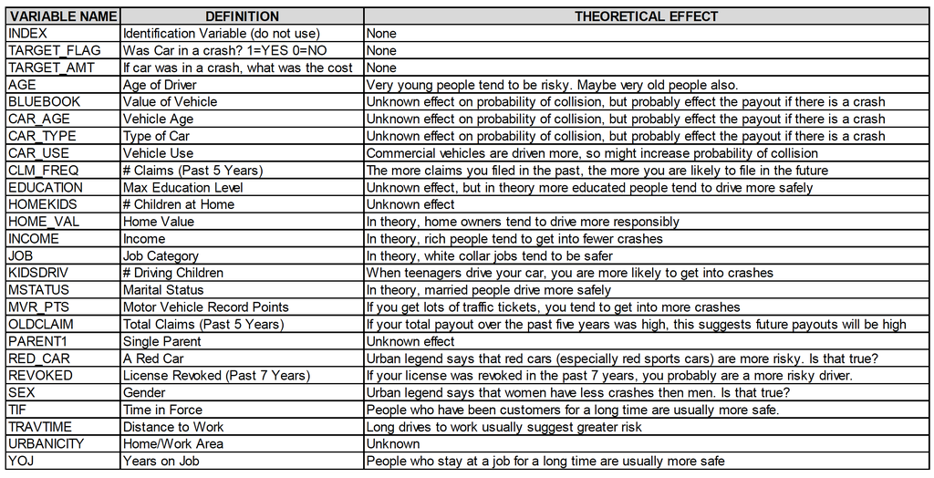

## 2.2 Missing Data

An important aspect of any dataset is to determine how much, if any, data is missing. We look at all the variables to see which if any have missing data. We look at the basic descriptive statistics as well as the missing data and percentages.

We start by looking at the dataset as a whole and determine how many complete rows, that is rows with data for all predictors, do we have.

```
##    Mode   FALSE    TRUE
## logical    2116    6045
```

With these results, if we remove all rows with incomplete rows, there will be a total of 6045 rows out of 8161 .If we eliminate all non-complete rows and keep only rows with data for all the predictors in the dataset, our new dataset will results in 74% of the total dataset. We create a subset of data with complete cases only to use later in our analysis.

```
## Observations: 6,045
## Variables: 26
## $ INDEX       <int> 1, 2, 4, 7, 12, 13, 14, 15, 16, 19, 20, 22, 23, 24...
## $ TARGET_FLAG <int> 0, 0, 0, 1, 1, 0, 1, 0, 0, 1, 0, 0, 0, 0, 1, 0, 0,...
## $ TARGET_AMT  <dbl> 0.000, 0.000, 0.000, 2946.000, 2501.000, 0.000, 60...
## $ KIDSDRIV    <int> 0, 0, 0, 0, 0, 0, 0, 0, 0, 0, 0, 0, 0, 0, 0, 0, 0,...
## $ AGE         <int> 60, 43, 35, 34, 34, 50, 53, 43, 55, 45, 39, 42, 34...
## $ HOMEKIDS    <int> 0, 0, 1, 1, 0, 0, 0, 0, 0, 0, 3, 0, 3, 2, 1, 0, 0,...
## $ YOJ         <int> 11, 11, 10, 12, 10, 7, 14, 5, 11, 0, 12, 11, 13, 1...
## $ INCOME      <fct> "$67,349", "$91,449", "$16,039", "$125,301", "$62,...
## $ PARENT1     <fct> No, No, No, Yes, No, No, No, No, No, No, Yes, No, ...
## $ HOME_VAL    <fct> "$0", "$257,252", "$124,191", "$0", "$0", "$0", "$...
## $ MSTATUS     <fct> z_No, z_No, Yes, z_No, z_No, z_No, z_No, Yes, Yes,...
## $ SEX         <fct> M, M, z_F, z_F, z_F, M, z_F, z_F, M, z_F, z_F, M, ...
## $ EDUCATION   <fct> PhD, z_High School, z_High School, Bachelors, Bach...
## $ JOB         <fct> Professional, z_Blue Collar, Clerical, z_Blue Coll...
## $ TRAVTIME    <int> 14, 22, 5, 46, 34, 48, 15, 36, 25, 48, 43, 42, 27,...
## $ CAR_USE     <fct> Private, Commercial, Private, Commercial, Private,...
## $ BLUEBOOK    <fct> "$14,230", "$14,940", "$4,010", "$17,430", "$11,20...
## $ TIF         <int> 11, 1, 4, 1, 1, 7, 1, 7, 7, 1, 6, 6, 7, 4, 6, 6, 1...
## $ CAR_TYPE    <fct> Minivan, Minivan, z_SUV, Sports Car, z_SUV, Van, S...
## $ RED_CAR     <fct> yes, yes, no, no, no, no, no, no, yes, no, no, no,...
## $ OLDCLAIM    <fct> "$4,461", "$0", "$38,690", "$0", "$0", "$0", "$0",...
## $ CLM_FREQ    <int> 2, 0, 2, 0, 0, 0, 0, 0, 2, 0, 0, 0, 0, 0, 2, 1, 0,...
## $ REVOKED     <fct> No, No, No, No, No, No, No, No, Yes, No, No, No, N...
## $ MVR_PTS     <int> 3, 0, 3, 0, 0, 1, 0, 0, 3, 3, 0, 0, 0, 0, 0, 5, 1,...
## $ CAR_AGE     <int> 18, 1, 10, 7, 1, 17, 11, 1, 9, 5, 13, 16, 20, 7, 1...
## $ URBANICITY  <fct> Highly Urban/ Urban, Highly Urban/ Urban, Highly U...
```

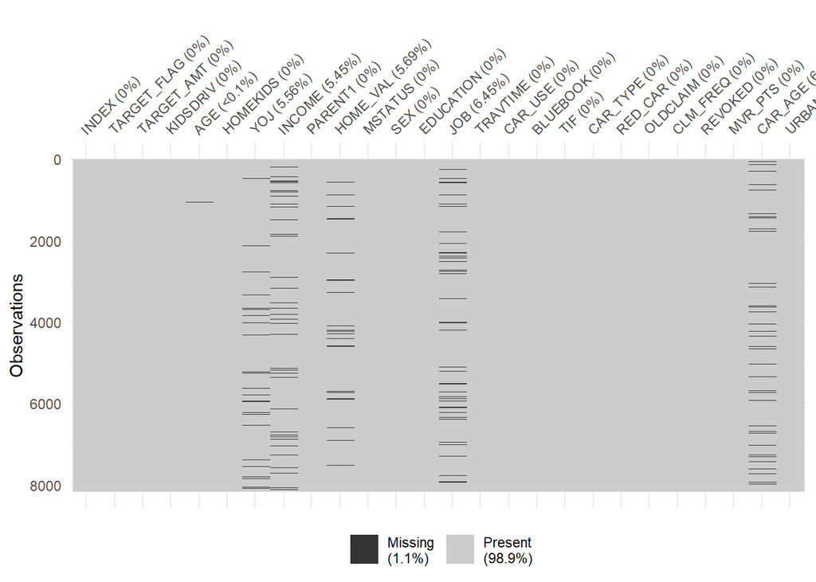

We look closer at the missing data and look at the intersection of predictors with missing data. We find that the bulk of the missing data is for predictors with no intersection with other missing predictor data.

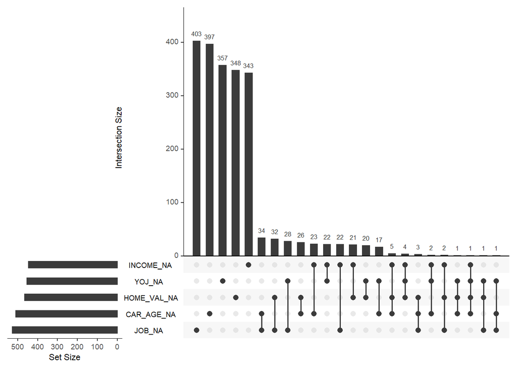

Having this detail in missing data might be of importance when looking at models. In the next Data Preparation section we will handle these missing cases and build a data set with data for all predictors in all rows.

## 2.3 Data Exploration

Using TARGET_FLAG as response variables we confirm when TARGET_FLAG is 1 TARGET_AMOUNT >0 and when TARGET_FLAG is 0 when TARGET_AMOUNT = 0

```r
nrow(subset(InsTrain,TARGET_FLAG == 0))
```

```
## [1] 6008
```

```r
nrow(subset(InsTrain,TARGET_AMT == 0))
```

```
## [1] 6008
```

```r
nrow(subset(InsTrain,TARGET_FLAG > 0))
```

```
## [1] 2153
```

```r
nrow(subset(InsTrain,TARGET_AMT > 0))
```

```
## [1] 2153
```

A glimpse of the data shows that the following columns should be integers and not Factors:

- INCOME
- HOME_VAL
- BLUEBOOK
- OLDCLAIM

We display and view data with all cases and only complete cases

```
## INCOME PARENT1 HOME_VAL MSTATUS SEX EDUCATION JOB CAR_USE BLUEBOOK CAR_TYPE RED_CAR OLDCLAIM REVOKED URBANICITY
```

```
## Observations: 8,161
## Variables: 26
## $ INDEX       <int> 1, 2, 4, 5, 6, 7, 8, 11, 12, 13, 14, 15, 16, 17, 1...
## $ TARGET_FLAG <int> 0, 0, 0, 0, 0, 1, 0, 1, 1, 0, 1, 0, 0, 1, 1, 0, 0,...
## $ TARGET_AMT  <dbl> 0.000, 0.000, 0.000, 0.000, 0.000, 2946.000, 0.000...
## $ KIDSDRIV    <int> 0, 0, 0, 0, 0, 0, 0, 1, 0, 0, 0, 0, 0, 0, 0, 0, 0,...
## $ AGE         <int> 60, 43, 35, 51, 50, 34, 54, 37, 34, 50, 53, 43, 55...
## $ HOMEKIDS    <int> 0, 0, 1, 0, 0, 1, 0, 2, 0, 0, 0, 0, 0, 0, 0, 3, 0,...
## $ YOJ         <int> 11, 11, 10, 14, NA, 12, NA, NA, 10, 7, 14, 5, 11, ...
## $ INCOME      <fct> "$67,349", "$91,449", "$16,039", NA, "$114,986", "...
## $ PARENT1     <fct> No, No, No, No, No, Yes, No, No, No, No, No, No, N...
## $ HOME_VAL    <fct> "$0", "$257,252", "$124,191", "$306,251", "$243,92...
## $ MSTATUS     <fct> z_No, z_No, Yes, Yes, Yes, z_No, Yes, Yes, z_No, z...
## $ SEX         <fct> M, M, z_F, M, z_F, z_F, z_F, M, z_F, M, z_F, z_F, ...
## $ EDUCATION   <fct> PhD, z_High School, z_High School, <High School, P...
## $ JOB         <fct> Professional, z_Blue Collar, Clerical, z_Blue Coll...
## $ TRAVTIME    <int> 14, 22, 5, 32, 36, 46, 33, 44, 34, 48, 15, 36, 25,...
## $ CAR_USE     <fct> Private, Commercial, Private, Private, Private, Co...
## $ BLUEBOOK    <fct> "$14,230", "$14,940", "$4,010", "$15,440", "$18,00...
## $ TIF         <int> 11, 1, 4, 7, 1, 1, 1, 1, 1, 7, 1, 7, 7, 6, 1, 6, 6...
## $ CAR_TYPE    <fct> Minivan, Minivan, z_SUV, Minivan, z_SUV, Sports Ca...
## $ RED_CAR     <fct> yes, yes, no, yes, no, no, no, yes, no, no, no, no...
## $ OLDCLAIM    <fct> "$4,461", "$0", "$38,690", "$0", "$19,217", "$0", ...
## $ CLM_FREQ    <int> 2, 0, 2, 0, 2, 0, 0, 1, 0, 0, 0, 0, 2, 0, 0, 0, 0,...
## $ REVOKED     <fct> No, No, No, No, Yes, No, No, Yes, No, No, No, No, ...
## $ MVR_PTS     <int> 3, 0, 3, 0, 3, 0, 0, 10, 0, 1, 0, 0, 3, 3, 3, 0, 0...
## $ CAR_AGE     <int> 18, 1, 10, 6, 17, 7, 1, 7, 1, 17, 11, 1, 9, 10, 5,...
## $ URBANICITY  <fct> Highly Urban/ Urban, Highly Urban/ Urban, Highly U...
```

We use Sapply function to review which columns have NA Values. It display columns and percent of values that are missing.

```
##       INDEX TARGET_FLAG  TARGET_AMT    KIDSDRIV         AGE    HOMEKIDS
##         0.0         0.0         0.0         0.0         0.1         0.0
##         YOJ      INCOME     PARENT1    HOME_VAL     MSTATUS         SEX
##         5.6         5.5         0.0         5.7         0.0         0.0
##   EDUCATION         JOB    TRAVTIME     CAR_USE    BLUEBOOK         TIF
##         0.0         6.4         0.0         0.0         0.0         0.0
##    CAR_TYPE     RED_CAR    OLDCLAIM    CLM_FREQ     REVOKED     MVR_PTS
##         0.0         0.0         0.0         0.0         0.0         0.0
##     CAR_AGE  URBANICITY
##         6.2         0.0
```

## 2.4 Data Preperation

As revealed earlier there were a list of columns that we factors that should be integers. We start by converting the columns to numeric.

```
## Observations: 8,161
## Variables: 4
## $ INCOME   <fct> "$67,349", "$91,449", "$16,039", NA, "$114,986", "$12...
## $ HOME_VAL <fct> "$0", "$257,252", "$124,191", "$306,251", "$243,925",...
## $ BLUEBOOK <fct> "$14,230", "$14,940", "$4,010", "$15,440", "$18,000",...
## $ OLDCLAIM <fct> "$4,461", "$0", "$38,690", "$0", "$19,217", "$0", "$0...
## Observations: 8,161
## Variables: 4
## $ INCOME   <int> 67349, 91449, 16039, NA, 114986, 125301, 18755, 10796...
## $ HOME_VAL <int> 0, 257252, 124191, 306251, 243925, 0, NA, 333680, 0, ...
## $ BLUEBOOK <int> 14230, 14940, 4010, 15440, 18000, 17430, 8780, 16970,...
## $ OLDCLAIM <int> 4461, 0, 38690, 0, 19217, 0, 0, 2374, 0, 0, 0, 0, 502...
```

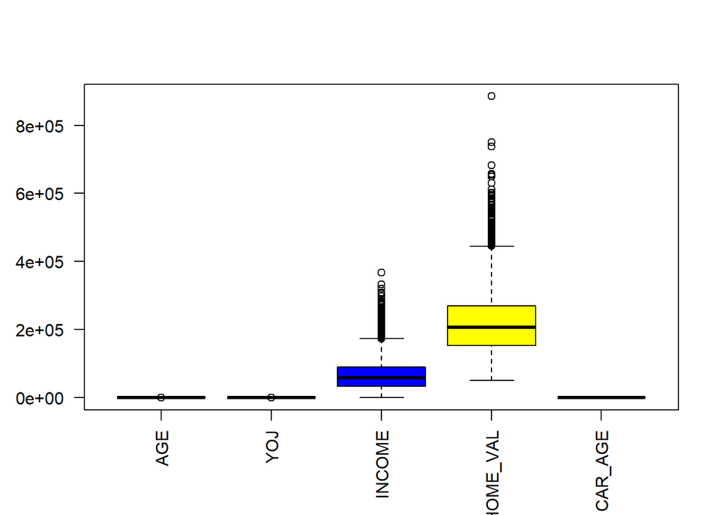

```
##          vars    n      mean       sd median   trimmed      mad   min
## AGE         1 8155     44.79     8.63     45     44.83     8.90    16
## YOJ         2 7707     10.50     4.09     11     11.07     2.97     0
## INCOME      3 7101  67258.94 45810.25  58438  61952.41 39533.53     5
## HOME_VAL    4 5403 220620.68 96145.72 206692 211487.81 85498.58 50223
## CAR_AGE     5 7651      8.33     5.70      8      7.96     7.41    -3
##             max  range  skew kurtosis      se
## AGE          81     65 -0.03    -0.06    0.10
## YOJ          23     23 -1.20     1.18    0.05
## INCOME   367030 367025  1.30     2.50  543.63
## HOME_VAL 885282 835059  1.09     1.97 1308.01
## CAR_AGE      28     31  0.28    -0.75    0.07
```

```
##       INDEX TARGET_FLAG  TARGET_AMT    KIDSDRIV         AGE    HOMEKIDS
##         0.0         0.0         0.0         0.0         0.1         0.0
##         YOJ      INCOME     PARENT1    HOME_VAL     MSTATUS         SEX
##         5.6        13.0         0.0        33.8         0.0         0.0
##   EDUCATION         JOB    TRAVTIME     CAR_USE    BLUEBOOK         TIF
##         0.0         6.4         0.0         0.0         0.0         0.0
##    CAR_TYPE     RED_CAR    OLDCLAIM    CLM_FREQ     REVOKED     MVR_PTS
##         0.0         0.0         0.0         0.0         0.0         0.0
##     CAR_AGE  URBANICITY
##         6.2         0.0
```

```
##      Clerical        Doctor    Home Maker        Lawyer       Manager
##          1271           246           641           835           988
##  Professional       Student z_Blue Collar          NA's
##          1117           712          1825           526
```

```
## [1] 6
```

```
##      Clerical        Doctor    Home Maker        Lawyer       Manager
##          1271           246           641           835           988
##  Professional       Student z_Blue Collar
##          1117           712          2351
```

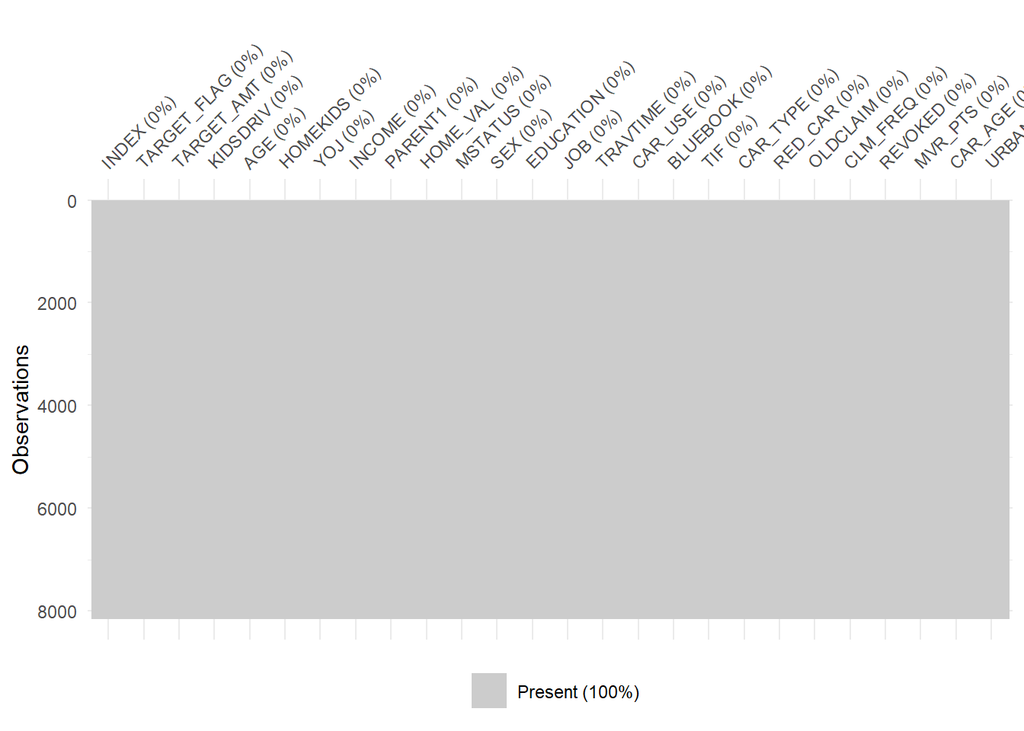

```
##          vars    n      mean       sd    median   trimmed      mad   min
## AGE         1 8161     44.79     8.62     45.00     44.83     8.90    16
## YOJ         2 8161     10.50     3.98     11.00     11.05     2.97     0
## INCOME      3 8161  67258.94 42731.37  66367.00  62497.52 36362.25     5
## HOME_VAL    4 8161 220620.68 78227.99 220620.68 214305.03 41344.79 50223
## CAR_AGE     5 8161      8.33     5.52      8.33      7.98     5.44    -3
##             max  range  skew kurtosis     se
## AGE          81     65 -0.03    -0.06   0.10
## YOJ          23     23 -1.24     1.42   0.04
## INCOME   367030 367025  1.40     3.32 473.02
## HOME_VAL 885282 835059  1.34     4.50 865.95
## CAR_AGE      28     31  0.29    -0.60   0.06
```

We have this way derived a dataset with no missing values. We can use this set of data for our modeling design. We chose to work with this data as opposed to the first “complete” set in which rows with missing data were eliminated.

# 3 Build Model

Modeling design will be divided in two phases. First we will design a model to predict if the person is in a car crash, that is predict TARGET_FLAG. In a second phase, we will predict TARGET_AMT, the cost of the crash.

## 3.1 TARGET_FLAG Modeling

This response variable being binary, o or 1, we will be looking at logistic regression models to find a good fit. We will start with a naive model with all the predictors included as a baseline. First approach will be to simply the model by reducing the predictors used. We will look at several model metrics such as AIC, BIC. We will also include confusion tables and ROC plot to better understand each model.

**Model 1: all predictors**

We start out with a straightforward logit logistical regression with all predictors included. As a note, we need to make sure we do not include the TARGET_AMT responce variable in our model as a predictor.

```
##
## Call:
## glm(formula = TARGET_FLAG ~ . - INDEX - TARGET_AMT, family = binomial(link = "logit"),
##     data = InsTrain)
##
## Deviance Residuals:
##     Min       1Q   Median       3Q      Max
## -2.5548  -0.7184  -0.4032   0.6346   3.1472
##
## Coefficients:
##                                   Estimate Std. Error z value Pr(>|z|)
## (Intercept)                     -4.750e-01  2.748e-01  -1.728 0.083915 .
## KIDSDRIV                         3.847e-01  6.101e-02   6.306 2.87e-10 ***
## AGE                             -8.588e-04  4.011e-03  -0.214 0.830483
## HOMEKIDS                         5.680e-02  3.720e-02   1.527 0.126829
## YOJ                             -1.914e-02  8.888e-03  -2.154 0.031261 *
## INCOME                          -2.155e-06  1.162e-06  -1.855 0.063585 .
## PARENT1Yes                       3.795e-01  1.095e-01   3.467 0.000526 ***
## HOME_VAL                        -9.005e-07  5.908e-07  -1.524 0.127471
## MSTATUSz_No                      6.329e-01  7.272e-02   8.703  < 2e-16 ***
## SEXz_F                          -7.739e-02  1.118e-01  -0.692 0.488791
## EDUCATIONBachelors              -4.599e-01  1.144e-01  -4.018 5.86e-05 ***
## EDUCATIONMasters                -5.141e-01  1.532e-01  -3.357 0.000789 ***
## EDUCATIONPhD                    -4.617e-01  1.880e-01  -2.456 0.014063 *
## EDUCATIONz_High School          -1.365e-02  9.467e-02  -0.144 0.885335
## JOBDoctor                       -7.034e-01  2.656e-01  -2.648 0.008092 **
## JOBHome Maker                   -6.625e-02  1.425e-01  -0.465 0.642047
## JOBLawyer                       -1.851e-01  1.616e-01  -1.146 0.251943
## JOBManager                      -9.248e-01  1.356e-01  -6.822 8.98e-12 ***
## JOBProfessional                 -2.485e-01  1.215e-01  -2.045 0.040901 *
## JOBStudent                      -2.503e-03  1.301e-01  -0.019 0.984651
## JOBz_Blue Collar                -1.727e-01  1.049e-01  -1.645 0.099934 .
## TRAVTIME                         1.464e-02  1.878e-03   7.791 6.64e-15 ***
## CAR_USEPrivate                  -7.768e-01  9.085e-02  -8.550  < 2e-16 ***
## BLUEBOOK                        -2.204e-05  5.235e-06  -4.210 2.56e-05 ***
## TIF                             -5.561e-02  7.333e-03  -7.583 3.37e-14 ***
## CAR_TYPEPanel Truck              4.823e-01  1.577e-01   3.058 0.002230 **
## CAR_TYPEPickup                   5.241e-01  9.983e-02   5.250 1.52e-07 ***
## CAR_TYPESports Car               1.022e+00  1.297e-01   7.883 3.20e-15 ***
## CAR_TYPEVan                      5.776e-01  1.251e-01   4.618 3.87e-06 ***
## CAR_TYPEz_SUV                    7.609e-01  1.112e-01   6.842 7.83e-12 ***
## RED_CARyes                      -1.577e-03  8.608e-02  -0.018 0.985383
## OLDCLAIM                        -1.404e-05  3.902e-06  -3.598 0.000320 ***
## CLM_FREQ                         1.992e-01  2.847e-02   6.997 2.62e-12 ***
## REVOKEDYes                       8.955e-01  9.104e-02   9.837  < 2e-16 ***
## MVR_PTS                          1.152e-01  1.357e-02   8.489  < 2e-16 ***
## CAR_AGE                         -5.591e-04  7.516e-03  -0.074 0.940704
## URBANICITYz_Highly Rural/ Rural -2.383e+00  1.129e-01 -21.103  < 2e-16 ***
## ---
## Signif. codes:  0 '***' 0.001 '**' 0.01 '*' 0.05 '.' 0.1 ' ' 1
##
## (Dispersion parameter for binomial family taken to be 1)
##
##     Null deviance: 9418.0  on 8160  degrees of freedom
## Residual deviance: 7327.1  on 8124  degrees of freedom
## AIC: 7401.1
##
## Number of Fisher Scoring iterations: 5
```

**Model 2: reduced predictors**

```
##
## Call:
## glm(formula = TARGET_FLAG ~ . - INDEX - TARGET_AMT - AGE - INCOME -
##     JOB - BLUEBOOK - CAR_AGE - RED_CAR, family = binomial(link = "logit"),
##     data = InsTrain)
##
## Deviance Residuals:
##     Min       1Q   Median       3Q      Max
## -2.4982  -0.7289  -0.4194   0.6476   3.1224
##
## Coefficients:
##                                   Estimate Std. Error z value Pr(>|z|)
## (Intercept)                     -6.275e-01  1.842e-01  -3.406 0.000658 ***
## KIDSDRIV                         3.483e-01  5.950e-02   5.854 4.79e-09 ***
## HOMEKIDS                         9.058e-02  3.372e-02   2.687 0.007219 **
## YOJ                             -2.828e-02  7.362e-03  -3.842 0.000122 ***
## PARENT1Yes                       3.696e-01  1.077e-01   3.432 0.000598 ***
## HOME_VAL                        -2.108e-06  4.702e-07  -4.483 7.38e-06 ***
## MSTATUSz_No                      6.213e-01  7.191e-02   8.641  < 2e-16 ***
## SEXz_F                          -2.529e-01  8.790e-02  -2.878 0.004007 **
## EDUCATIONBachelors              -7.334e-01  9.571e-02  -7.663 1.82e-14 ***
## EDUCATIONMasters                -8.017e-01  1.049e-01  -7.642 2.14e-14 ***
## EDUCATIONPhD                    -9.544e-01  1.391e-01  -6.864 6.70e-12 ***
## EDUCATIONz_High School          -1.246e-01  9.123e-02  -1.366 0.172010
## TRAVTIME                         1.496e-02  1.866e-03   8.017 1.08e-15 ***
## CAR_USEPrivate                  -8.298e-01  7.286e-02 -11.388  < 2e-16 ***
## TIF                             -5.428e-02  7.270e-03  -7.466 8.26e-14 ***
## CAR_TYPEPanel Truck              1.106e-01  1.317e-01   0.839 0.401223
## CAR_TYPEPickup                   5.561e-01  9.698e-02   5.734 9.81e-09 ***
## CAR_TYPESports Car               1.208e+00  1.201e-01  10.053  < 2e-16 ***
## CAR_TYPEVan                      4.075e-01  1.186e-01   3.435 0.000592 ***
## CAR_TYPEz_SUV                    9.573e-01  1.017e-01   9.411  < 2e-16 ***
## OLDCLAIM                        -1.403e-05  3.862e-06  -3.632 0.000281 ***
## CLM_FREQ                         2.006e-01  2.824e-02   7.104 1.21e-12 ***
## REVOKEDYes                       9.037e-01  9.019e-02  10.021  < 2e-16 ***
## MVR_PTS                          1.205e-01  1.347e-02   8.946  < 2e-16 ***
## URBANICITYz_Highly Rural/ Rural -2.283e+00  1.119e-01 -20.400  < 2e-16 ***
## ---
## Signif. codes:  0 '***' 0.001 '**' 0.01 '*' 0.05 '.' 0.1 ' ' 1
##
## (Dispersion parameter for binomial family taken to be 1)
##
##     Null deviance: 9418.0  on 8160  degrees of freedom
## Residual deviance: 7425.7  on 8136  degrees of freedom
## AIC: 7475.7
##
## Number of Fisher Scoring iterations: 5
```

### 3.1.1 AIC Step Method Model 3

Another way of selecting which predictors to use in the model is by calculating the AIC of the model. This metric is similar to the adjusted R-square of a model in that it penalizes models with more predictors over simpler model with few predictors. We use Stepwise function in r to find the lowest AIC with different predictors.

```
## Start:  AIC=7401.13
## TARGET_FLAG ~ (INDEX + TARGET_AMT + KIDSDRIV + AGE + HOMEKIDS +
##     YOJ + INCOME + PARENT1 + HOME_VAL + MSTATUS + SEX + EDUCATION +
##     JOB + TRAVTIME + CAR_USE + BLUEBOOK + TIF + CAR_TYPE + RED_CAR +
##     OLDCLAIM + CLM_FREQ + REVOKED + MVR_PTS + CAR_AGE + URBANICITY) -
##     INDEX - TARGET_AMT
##
##              Df Deviance    AIC
## - RED_CAR     1   7327.1 7399.1
## - CAR_AGE     1   7327.1 7399.1
## - AGE         1   7327.2 7399.2
## - SEX         1   7327.6 7399.6
## <none>            7327.1 7401.1
## - HOMEKIDS    1   7329.4 7401.4
## - HOME_VAL    1   7329.5 7401.5
## - INCOME      1   7330.6 7402.6
## - YOJ         1   7331.8 7403.8
## - PARENT1     1   7339.2 7411.2
## - OLDCLAIM    1   7340.3 7412.3
## - BLUEBOOK    1   7345.2 7417.2
## - EDUCATION   4   7356.1 7422.1
## - KIDSDRIV    1   7366.9 7438.9
## - CLM_FREQ    1   7375.4 7447.4
## - JOB         7   7390.8 7450.8
## - TIF         1   7386.8 7458.8
## - TRAVTIME    1   7388.0 7460.0
## - MVR_PTS     1   7399.8 7471.8
## - CAR_USE     1   7401.4 7473.4
## - MSTATUS     1   7402.8 7474.8
## - CAR_TYPE    5   7415.2 7479.2
## - REVOKED     1   7422.2 7494.2
## - URBANICITY  1   7971.7 8043.7
##
## Step:  AIC=7399.13
## TARGET_FLAG ~ KIDSDRIV + AGE + HOMEKIDS + YOJ + INCOME + PARENT1 +
##     HOME_VAL + MSTATUS + SEX + EDUCATION + JOB + TRAVTIME + CAR_USE +
##     BLUEBOOK + TIF + CAR_TYPE + OLDCLAIM + CLM_FREQ + REVOKED +
##     MVR_PTS + CAR_AGE + URBANICITY
##
##              Df Deviance    AIC
```

[output cut: 95 more lines]

```
## - PARENT1     1   7339.9 7403.9
## - OLDCLAIM    1   7340.9 7404.9
## - BLUEBOOK    1   7354.0 7418.0
## - EDUCATION   4   7366.4 7424.4
## - KIDSDRIV    1   7368.4 7432.4
## - CLM_FREQ    1   7376.1 7440.1
## - JOB         7   7391.2 7443.2
## - TIF         1   7387.4 7451.4
## - TRAVTIME    1   7388.7 7452.7
## - MVR_PTS     1   7400.4 7464.4
## - CAR_USE     1   7401.8 7465.8
## - MSTATUS     1   7403.7 7467.7
## - REVOKED     1   7423.1 7487.1
## - CAR_TYPE    5   7433.7 7489.7
## - URBANICITY  1   7973.3 8037.3
```

```
##
## Call:
## glm(formula = TARGET_FLAG ~ KIDSDRIV + HOMEKIDS + YOJ + INCOME +
##     PARENT1 + HOME_VAL + MSTATUS + EDUCATION + JOB + TRAVTIME +
##     CAR_USE + BLUEBOOK + TIF + CAR_TYPE + OLDCLAIM + CLM_FREQ +
##     REVOKED + MVR_PTS + URBANICITY, family = binomial(link = "logit"),
##     data = InsTrain)
##
## Deviance Residuals:
##     Min       1Q   Median       3Q      Max
## -2.5546  -0.7187  -0.4041   0.6353   3.1526
##
## Coefficients:
##                                   Estimate Std. Error z value Pr(>|z|)
## (Intercept)                     -5.106e-01  2.178e-01  -2.345 0.019047 *
## KIDSDRIV                         3.823e-01  6.002e-02   6.370 1.88e-10 ***
## HOMEKIDS                         5.820e-02  3.452e-02   1.686 0.091808 .
## YOJ                             -1.934e-02  8.772e-03  -2.205 0.027427 *
## INCOME                          -2.171e-06  1.161e-06  -1.869 0.061576 .
## PARENT1Yes                       3.804e-01  1.090e-01   3.491 0.000481 ***
## HOME_VAL                        -9.027e-07  5.898e-07  -1.531 0.125877
## MSTATUSz_No                      6.331e-01  7.264e-02   8.716  < 2e-16 ***
## EDUCATIONBachelors              -4.625e-01  1.077e-01  -4.293 1.76e-05 ***
## EDUCATIONMasters                -5.204e-01  1.335e-01  -3.899 9.66e-05 ***
## EDUCATIONPhD                    -4.712e-01  1.731e-01  -2.721 0.006501 **
## EDUCATIONz_High School          -1.446e-02  9.436e-02  -0.153 0.878209
## JOBDoctor                       -6.976e-01  2.651e-01  -2.632 0.008499 **
## JOBHome Maker                   -8.113e-02  1.406e-01  -0.577 0.563927
## JOBLawyer                       -1.849e-01  1.610e-01  -1.148 0.251040
## JOBManager                      -9.240e-01  1.352e-01  -6.833 8.32e-12 ***
## JOBProfessional                 -2.488e-01  1.214e-01  -2.050 0.040397 *
## JOBStudent                      -4.305e-03  1.299e-01  -0.033 0.973563
## JOBz_Blue Collar                -1.714e-01  1.049e-01  -1.634 0.102164
## TRAVTIME                         1.464e-02  1.878e-03   7.796 6.39e-15 ***
## CAR_USEPrivate                  -7.756e-01  9.080e-02  -8.542  < 2e-16 ***
## BLUEBOOK                        -2.383e-05  4.700e-06  -5.070 3.97e-07 ***
## TIF                             -5.559e-02  7.332e-03  -7.583 3.39e-14 ***
## CAR_TYPEPanel Truck              5.273e-01  1.467e-01   3.594 0.000326 ***
## CAR_TYPEPickup                   5.228e-01  9.974e-02   5.242 1.59e-07 ***
## CAR_TYPESports Car               9.666e-01  1.073e-01   9.007  < 2e-16 ***
## CAR_TYPEVan                      6.030e-01  1.208e-01   4.993 5.96e-07 ***
## CAR_TYPEz_SUV                    7.069e-01  8.587e-02   8.232  < 2e-16 ***
## OLDCLAIM                        -1.404e-05  3.902e-06  -3.599 0.000320 ***
## CLM_FREQ                         1.993e-01  2.846e-02   7.002 2.52e-12 ***
## REVOKEDYes                       8.966e-01  9.102e-02   9.850  < 2e-16 ***
## MVR_PTS                          1.152e-01  1.356e-02   8.494  < 2e-16 ***
## URBANICITYz_Highly Rural/ Rural -2.385e+00  1.129e-01 -21.115  < 2e-16 ***
## ---
## Signif. codes:  0 '***' 0.001 '**' 0.01 '*' 0.05 '.' 0.1 ' ' 1
##
## (Dispersion parameter for binomial family taken to be 1)
##
##     Null deviance: 9418.0  on 8160  degrees of freedom
## Residual deviance: 7327.7  on 8128  degrees of freedom
## AIC: 7393.7
##
## Number of Fisher Scoring iterations: 5
```

### 3.1.2 BIC Method Model 4

To determine the number of predictors and which predictors to be used we will use the Bayesian Information Criterion (BIC).

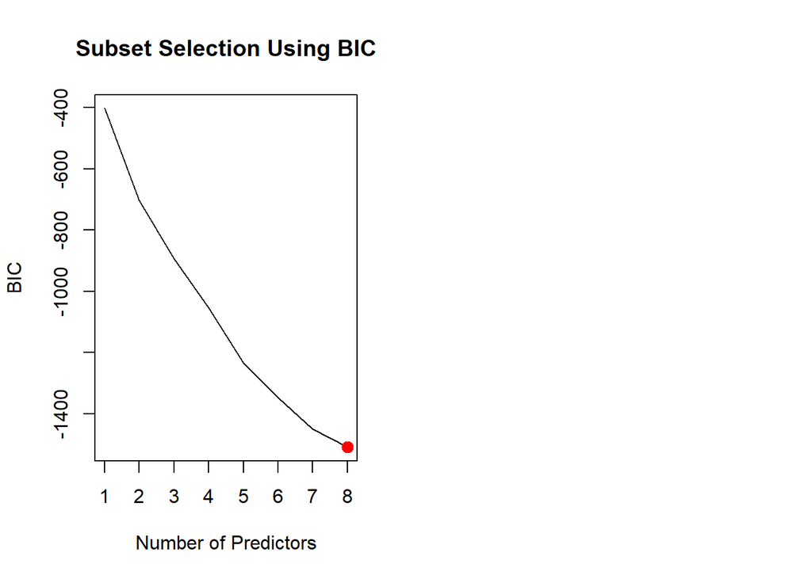

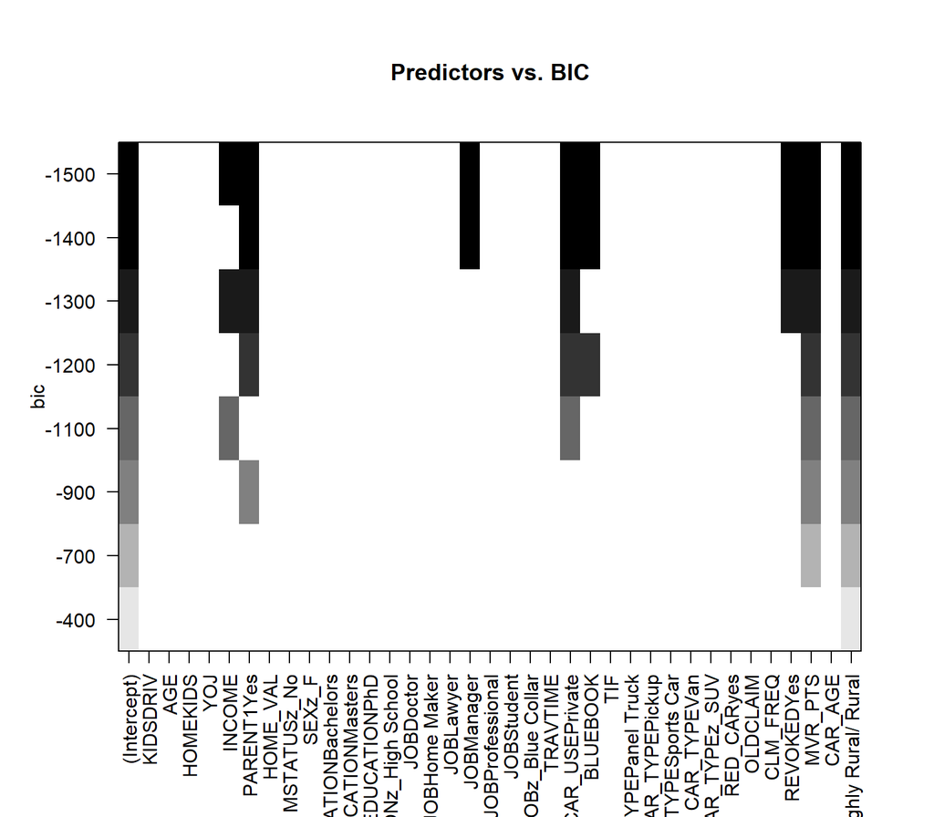

|  | Estimate | Std. Error | z value | Pr(>\|z\|) |
| --- | --- | --- | --- | --- |
| **(Intercept)** | -0.2576 | 0.125 | -2.061 | 0.03932 |
| **PARENT1Yes** | 0.9691 | 0.07619 | 12.72 | 4.658e-37 |
| **HOME_VAL** | -3.481e-06 | 4.244e-07 | -8.201 | 2.387e-16 |
| **CAR_USEPrivate** | -0.8617 | 0.06755 | -12.76 | 2.888e-37 |
| **CAR_TYPEPanel Truck** | 0.1519 | 0.1238 | 1.227 | 0.2197 |
| **CAR_TYPEPickup** | 0.5368 | 0.09355 | 5.738 | 9.6e-09 |
| **CAR_TYPESports Car** | 1.022 | 0.1012 | 10.09 | 5.897e-24 |
| **CAR_TYPEVan** | 0.3704 | 0.1135 | 3.264 | 0.001097 |
| **CAR_TYPEz_SUV** | 0.7982 | 0.08094 | 9.862 | 6.074e-23 |
| **REVOKEDYes** | 0.78 | 0.07661 | 10.18 | 2.393e-24 |
| **MVR_PTS** | 0.158 | 0.01225 | 12.9 | 4.487e-38 |
| **URBANICITYz_Highly Rural/ Rural** | -2.044 | 0.1058 | -19.32 | 3.648e-83 |
| **CAR_AGE** | -0.036 | 0.005397 | -6.669 | 2.571e-11 |

(Dispersion parameter for binomial family taken to be 1 )

| Null deviance: | 9418 on 8160 degrees of freedom |
| --- | --- |
| Residual deviance: | 7827 on 8148 degrees of freedom |

### 3.1.5 Model 1 - General Model

**ROC Curve**

The ROC Curve helps measure true positives and true negative. A high AUC or area under the curve tells us the model is predicting well.

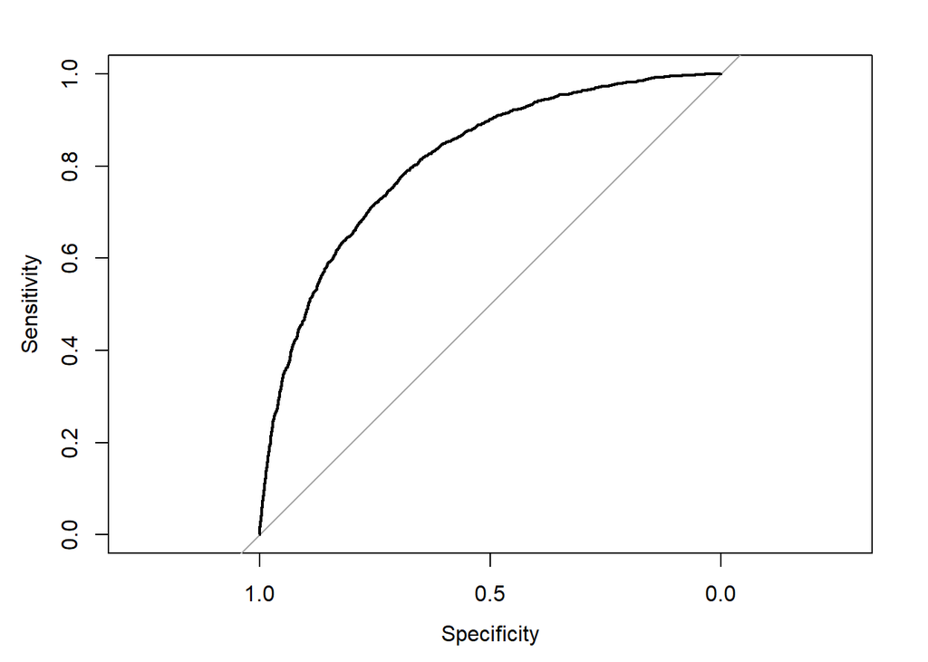

The AUC value of 0.81, tells us this model predicted values are acurate.

**Confusion Matrix**

```
##
## targethat    0    1
##         0 5554 1249
##         1  454  904
```

**Create a binned diagnostic plot of residuals vs prediction** There are definite patterns here, which bear investigating.

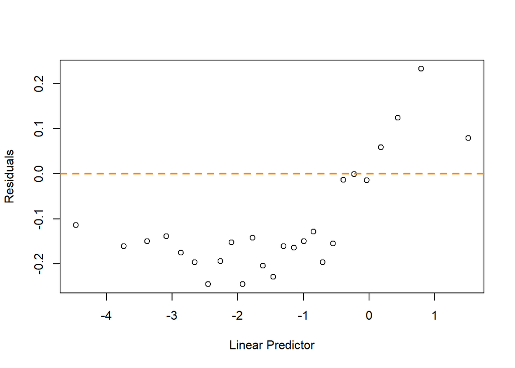

**Plot leverages.**

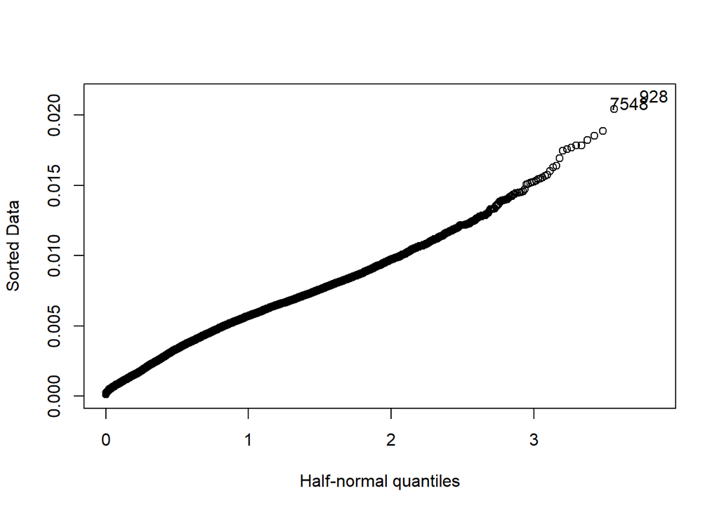

**Plot Goodness of fit**

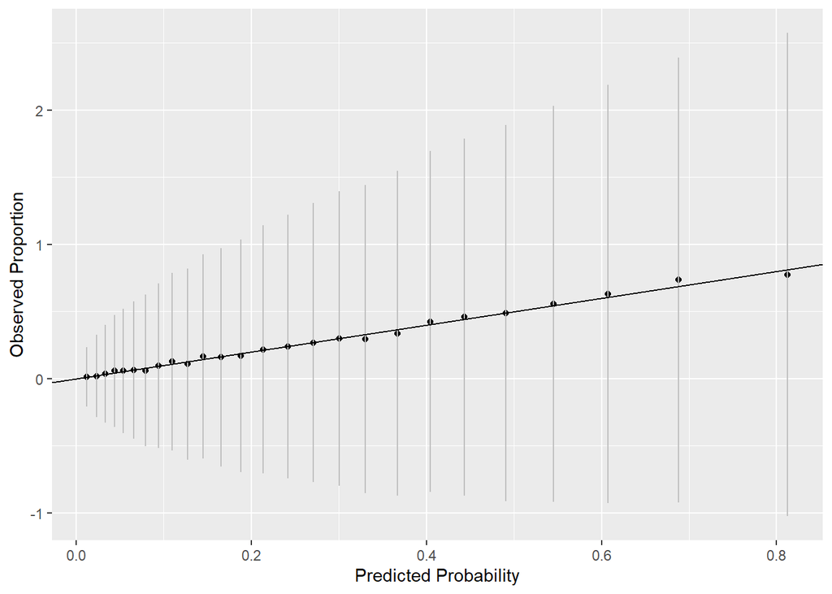

We see that our predictors fall close to the line.

### 3.1.6 Model 2 - Reduced General Model

**ROC Curve**

The ROC Curve helps measure true positives and true negative. A high AUC or area under the curve tells us the model is predicting well.

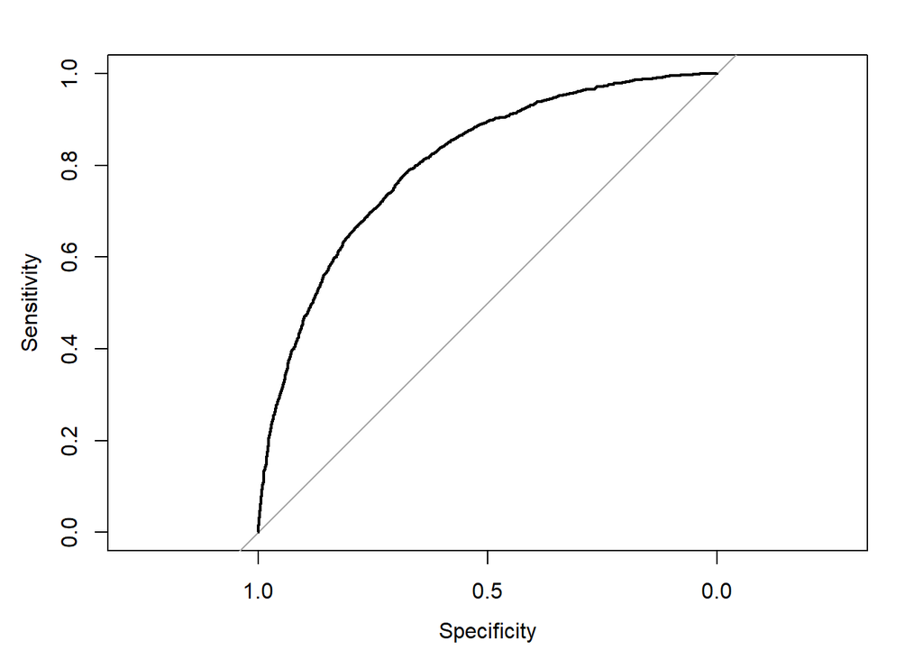

The AUC value of 0.8, tells us this model predicted values are acurate.

**Confusion Matrix**

```
##
## targethat    0    1
##         0 5559 1296
##         1  449  857
```

**Create a binned diagnostic plot of residuals vs prediction** There are definite patterns here, which bear investigating.

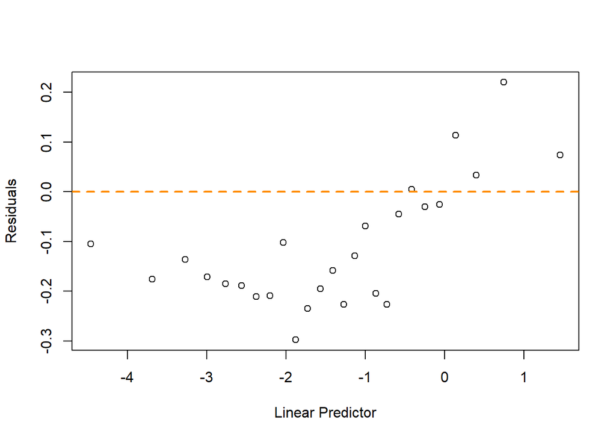

**Plot leverages.**

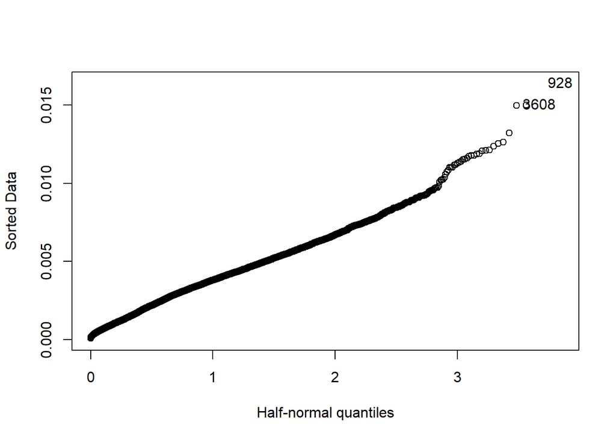

**Plot Goodness of fit**

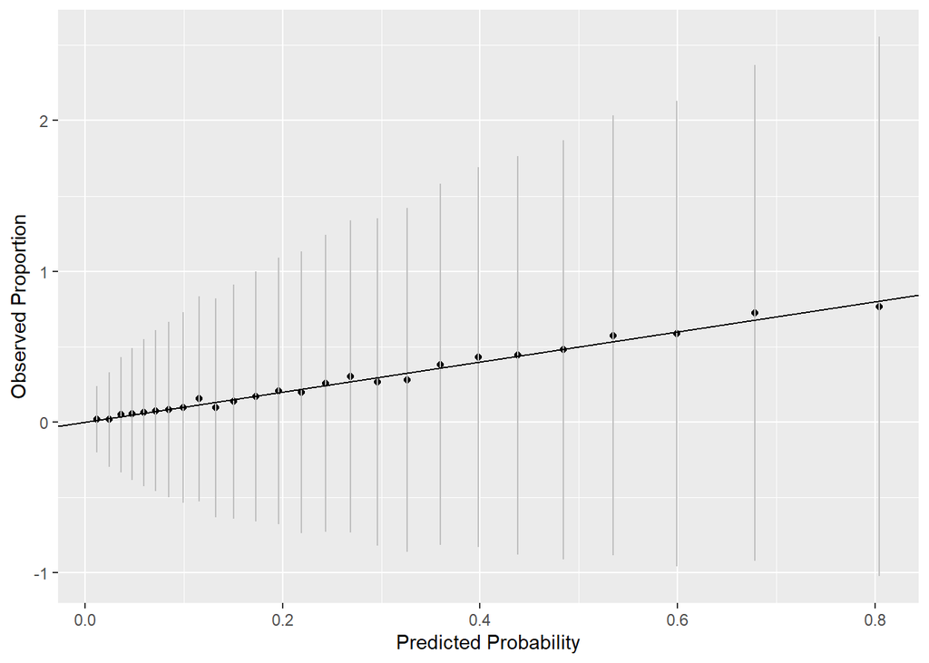

We see that our predictors fall close to the line.

### 3.1.7 Model 3 - Srep AIC Model

**ROC Curve**

The ROC Curve helps measure true positives and true negative. A high AUC or area under the curve tells us the model is predicting well.

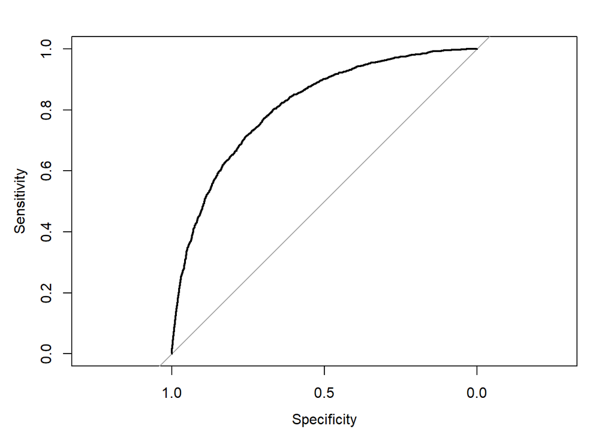

The AUC value of 0.81, tells us this model predicted values are acurate.

**Confusion Matrix**

```
##
## targethat    0    1
##         0 5555 1246
##         1  453  907
```

**Create a binned diagnostic plot of residuals vs prediction** There are definite patterns here, which bear investigating.

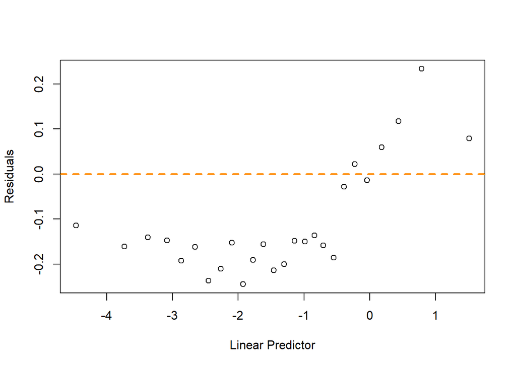

**Plot leverages.**

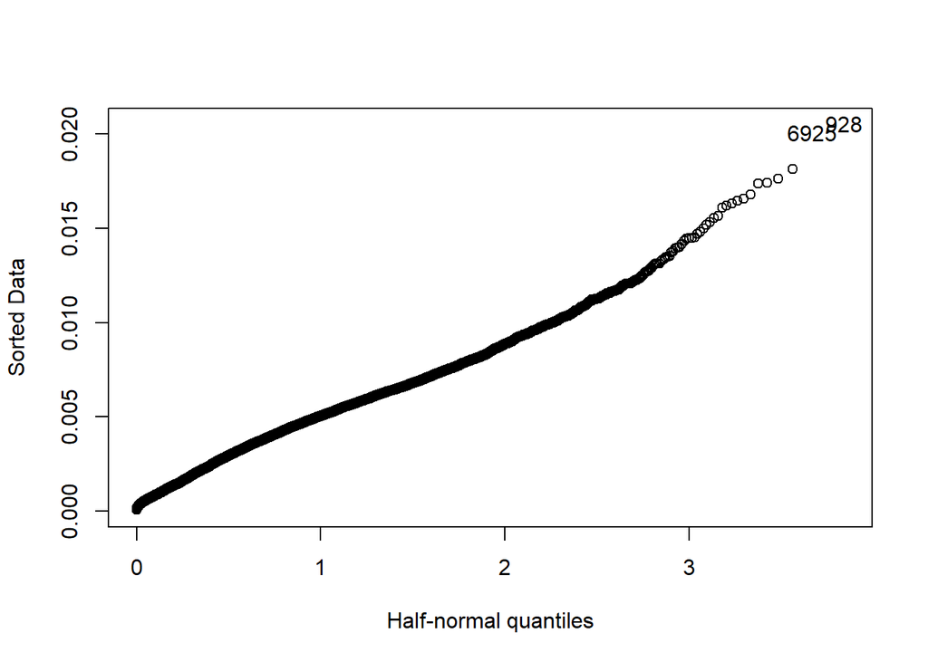

**Plot Goodness of fit**

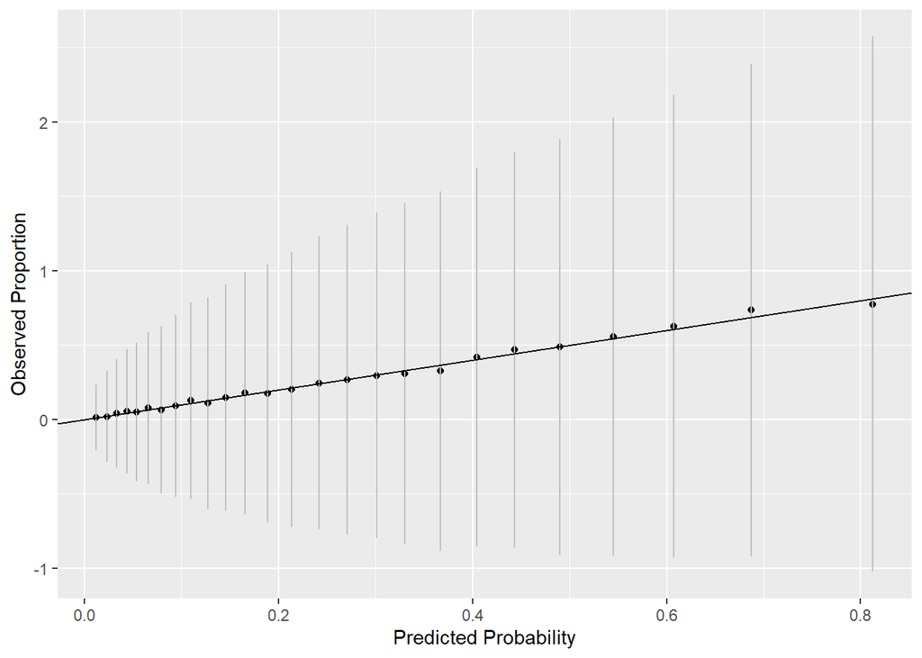

We see that our predictors fall close to the line.

### 3.1.8 Model 4 - Srep BIC Model

**ROC Curve**

The ROC Curve helps measure true positives and true negative. A high AUC or area under the curve tells us the model is predicting well.

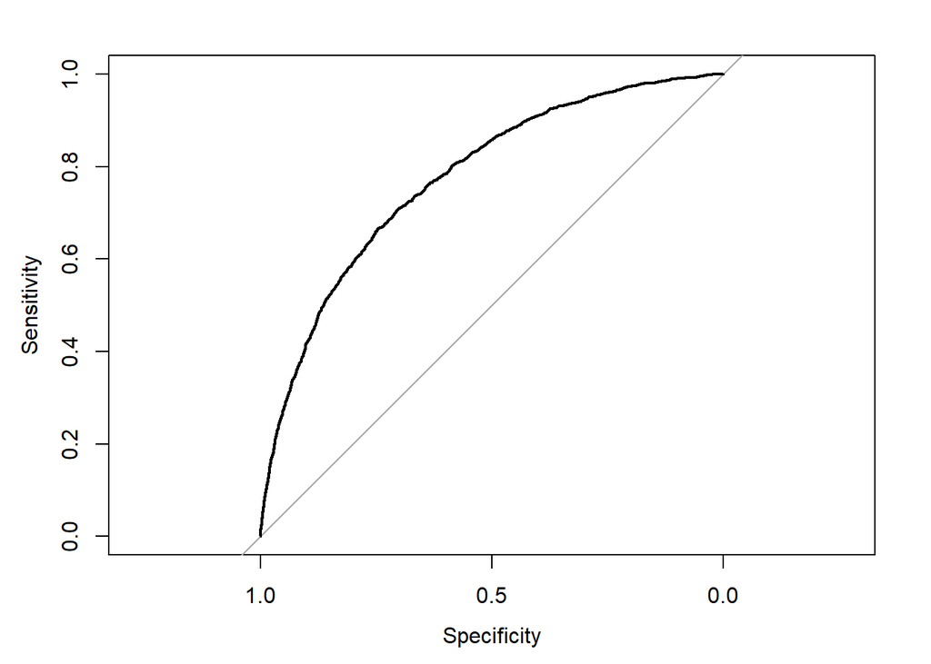

The AUC value of 0.77, tells us this model predicted values are acurate.

**Confusion Matrix**

```
##
## targethat    0    1
##         0 5621 1469
##         1  387  684
```

**Create a binned diagnostic plot of residuals vs prediction** There are definite patterns here, which bear investigating.

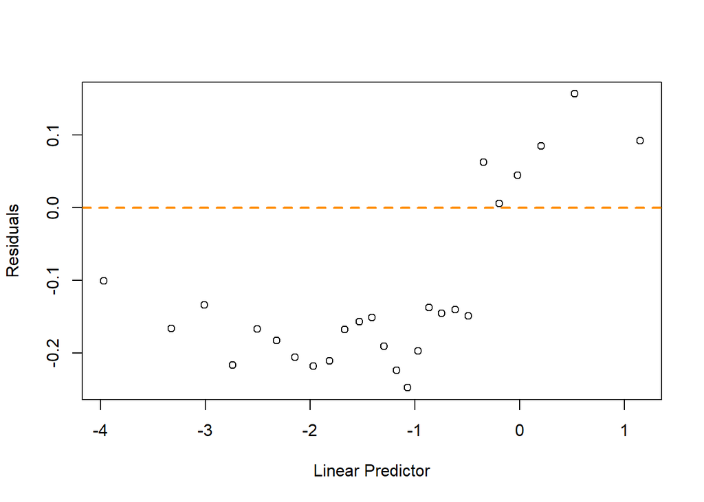

**Plot leverages.**

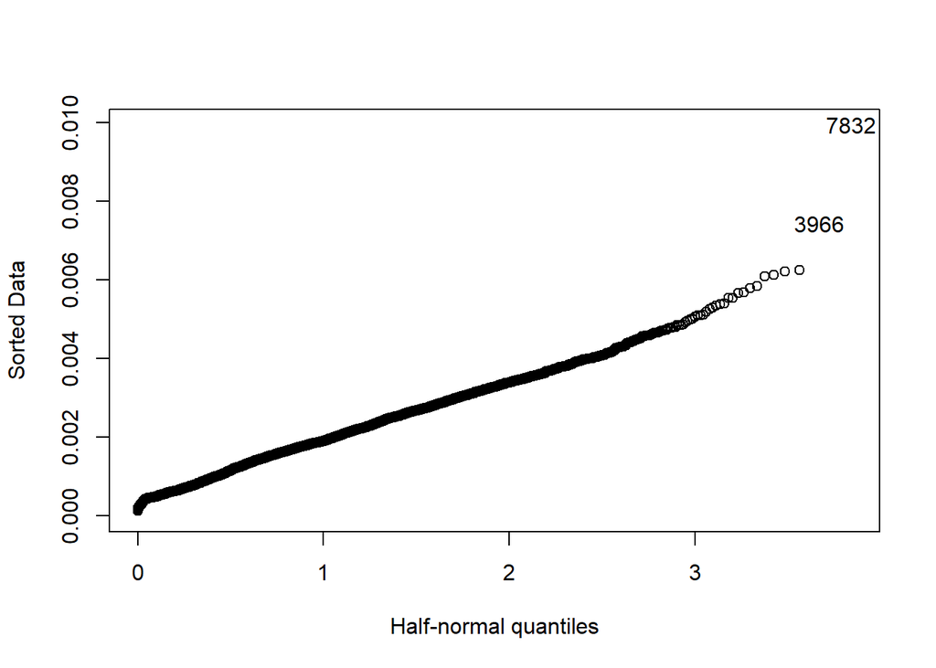

**Plot Goodness of fit**

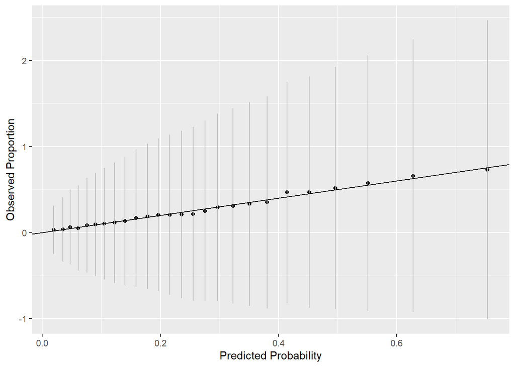

We see that our predictors fall close to the line.

### 3.1.9 Pick the best regression model

| Metric | Model 1 | Model 2 | Model 3 | Model 4 |
| --- | --- | --- | --- | --- |
| AIC | 7401.1283155 | 7475.6655813 | 7393.7376519 | 7853.4388014 |
| BIC | 7660.3918291 | 7650.843631 | 7624.9726775 | 7944.5313873 |

## 3.2 TARGET_AMT Modeling

**Model 1: all predictors**

Same as with the logistic model before, we start with a model that includes all predictors

```
##
## Call:
## lm(formula = TARGET_AMT ~ ., data = InsTrain)
##
## Residuals:
##    Min     1Q Median     3Q    Max
##  -6270   -470    -60    240 101124
##
## Coefficients:
##                                   Estimate Std. Error t value Pr(>|t|)
## (Intercept)                     -2.459e+02  5.642e+02  -0.436   0.6630
## INDEX                           -1.652e-03  1.480e-02  -0.112   0.9111
## TARGET_FLAG                      5.714e+03  1.145e+02  49.890  < 2e-16 ***
## KIDSDRIV                        -3.446e+01  9.913e+01  -0.348   0.7281
## AGE                              6.771e+00  6.168e+00   1.098   0.2724
## HOMEKIDS                         4.247e+01  5.726e+01   0.742   0.4583
## YOJ                              3.381e+00  1.360e+01   0.249   0.8037
## INCOME                          -1.833e-03  1.753e-03  -1.046   0.2958
## PARENT1Yes                       2.471e+02  2.367e+02   1.044   0.2965
## HOME_VAL                        -5.383e-04  9.701e-04  -0.555   0.5790
## MSTATUSz_No                      1.133e+02  1.100e+02   1.030   0.3032
## SEXz_F                          -2.884e+02  1.605e+02  -1.797   0.0724 .
## EDUCATIONBachelors               7.851e+01  1.770e+02   0.443   0.6574
## EDUCATIONMasters                 2.189e+02  2.328e+02   0.941   0.3470
## EDUCATIONPhD                     4.382e+02  2.818e+02   1.555   0.1199
## EDUCATIONz_High School          -1.192e+02  1.498e+02  -0.796   0.4262
## JOBDoctor                       -2.298e+02  3.521e+02  -0.653   0.5140
## JOBHome Maker                   -3.681e+01  2.179e+02  -0.169   0.8659
## JOBLawyer                        1.218e+02  2.400e+02   0.508   0.6118
## JOBManager                      -9.297e+01  1.979e+02  -0.470   0.6385
## JOBProfessional                  2.060e+02  1.854e+02   1.111   0.2666
## JOBStudent                      -1.108e+02  2.057e+02  -0.539   0.5900
## JOBz_Blue Collar                 6.661e+01  1.651e+02   0.404   0.6865
## TRAVTIME                         5.104e-01  2.824e+00   0.181   0.8566
## CAR_USEPrivate                  -1.815e+02  1.946e+02  -0.933   0.3511
## BLUEBOOK                         2.984e-02  7.530e-03   3.963 7.47e-05 ***
## TIF                             -3.081e+00  1.068e+01  -0.289   0.7729
## CAR_TYPEPanel Truck             -5.949e+01  2.365e+02  -0.252   0.8014
## CAR_TYPEPickup                   5.500e+00  1.628e+02   0.034   0.9730
## CAR_TYPESports Car               2.908e+02  2.368e+02   1.228   0.2196
## CAR_TYPEVan                      1.176e+02  1.887e+02   0.623   0.5334
## CAR_TYPEz_SUV                    2.228e+02  1.888e+02   1.180   0.2381
## RED_CARyes                      -3.108e+01  1.302e+02  -0.239   0.8113
## OLDCLAIM                         3.207e-03  6.507e-03   0.493   0.6221
## CLM_FREQ                        -4.632e+01  4.825e+01  -0.960   0.3371
## REVOKEDYes                      -2.503e+02  1.993e+02  -1.256   0.2093
## MVR_PTS                          7.021e+01  3.532e+01   1.988   0.0469 *
## CAR_AGE                         -2.867e+01  1.237e+01  -2.318   0.0205 *
## URBANICITYz_Highly Rural/ Rural -1.048e+02  2.608e+02  -0.402   0.6878
## predicted_m4                    -5.528e+02  9.071e+02  -0.609   0.5423
## ---
## Signif. codes:  0 '***' 0.001 '**' 0.01 '*' 0.05 '.' 0.1 ' ' 1
##
## Residual standard error: 3969 on 8121 degrees of freedom
## Multiple R-squared:  0.2913, Adjusted R-squared:  0.2879
## F-statistic: 85.61 on 39 and 8121 DF,  p-value: < 2.2e-16
```

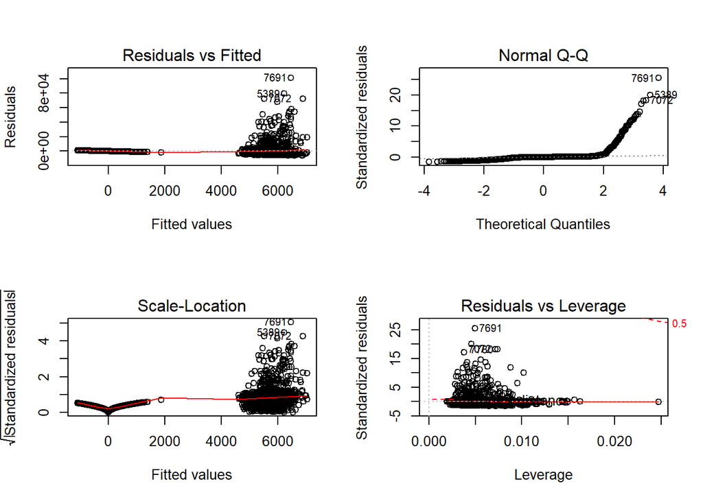

**Model 2: reduced predictors**

```
##
## Call:
## lm(formula = TARGET_AMT ~ +AGE + EDUCATION + REVOKED + MVR_PTS +
##     JOB + YOJ + CLM_FREQ + HOME_VAL + URBANICITY + PARENT1 +
##     MSTATUS + TRAVTIME + BLUEBOOK, data = InsTrain)
##
## Residuals:
##    Min     1Q Median     3Q    Max
##  -5426  -1685   -762    231 104766
##
## Coefficients:
##                                   Estimate Std. Error t value Pr(>|t|)
## (Intercept)                      8.602e+02  3.888e+02   2.212 0.026983 *
## AGE                              6.055e+00  6.519e+00   0.929 0.353029
## EDUCATIONBachelors              -3.005e+02  1.843e+02  -1.631 0.102943
## EDUCATIONMasters                -3.921e+02  2.269e+02  -1.728 0.083988 .
## EDUCATIONPhD                    -2.272e+02  2.832e+02  -0.802 0.422482
## EDUCATIONz_High School           4.008e+01  1.647e+02   0.243 0.807697
## REVOKEDYes                       5.263e+02  1.555e+02   3.384 0.000719 ***
## MVR_PTS                          1.908e+02  2.590e+01   7.369 1.89e-13 ***
## JOBDoctor                       -1.121e+03  3.979e+02  -2.818 0.004850 **
## JOBHome Maker                   -9.377e+01  2.451e+02  -0.383 0.702049
## JOBLawyer                       -4.025e+02  2.689e+02  -1.496 0.134568
## JOBManager                      -1.009e+03  2.247e+02  -4.492 7.15e-06 ***
## JOBProfessional                 -1.416e+02  2.116e+02  -0.669 0.503241
## JOBStudent                       2.289e+02  2.285e+02   1.002 0.316516
## JOBz_Blue Collar                 2.877e+02  1.695e+02   1.697 0.089718 .
## YOJ                             -6.070e+00  1.481e+01  -0.410 0.681963
## CLM_FREQ                         1.437e+02  4.896e+01   2.935 0.003346 **
## HOME_VAL                        -1.486e-03  8.013e-04  -1.855 0.063629 .
## URBANICITYz_Highly Rural/ Rural -1.568e+03  1.395e+02 -11.242  < 2e-16 ***
## PARENT1Yes                       8.668e+02  1.802e+02   4.810 1.54e-06 ***
## MSTATUSz_No                      5.094e+02  1.204e+02   4.231 2.35e-05 ***
## TRAVTIME                         1.223e+01  3.238e+00   3.777 0.000160 ***
## BLUEBOOK                         9.345e-03  6.611e-03   1.414 0.157475
## ---
## Signif. codes:  0 '***' 0.001 '**' 0.01 '*' 0.05 '.' 0.1 ' ' 1
##
## Residual standard error: 4571 on 8138 degrees of freedom
## Multiple R-squared:  0.05819,    Adjusted R-squared:  0.05565
## F-statistic: 22.86 on 22 and 8138 DF,  p-value: < 2.2e-16
```

This model shows an adj R2 as 0.056, and F-statistic of 22.86 with a small p-value.

Using the reduced predictors, let’s now do a stepwise regression:

**Model 3: Stepwise Regression**

```
## Start:  AIC=137577.4
## TARGET_AMT ~ +AGE + EDUCATION + REVOKED + MVR_PTS + JOB + YOJ +
##     CLM_FREQ + HOME_VAL + URBANICITY + PARENT1 + MSTATUS + TRAVTIME +
##     BLUEBOOK
##
##              Df  Sum of Sq        RSS    AIC
## - YOJ         1    3509293 1.7006e+11 137576
## - AGE         1   18026179 1.7007e+11 137576
## - EDUCATION   4  154037045 1.7021e+11 137577
## <none>                     1.7006e+11 137577
## - BLUEBOOK    1   41765295 1.7010e+11 137577
## - HOME_VAL    1   71907597 1.7013e+11 137579
## - CLM_FREQ    1  179988338 1.7024e+11 137584
## - REVOKED     1  239252115 1.7030e+11 137587
## - TRAVTIME    1  298134916 1.7035e+11 137590
## - MSTATUS     1  374117944 1.7043e+11 137593
## - PARENT1     1  483407044 1.7054e+11 137599
## - JOB         7 1186770595 1.7124e+11 137620
## - MVR_PTS     1 1134624808 1.7119e+11 137630
## - URBANICITY  1 2640997262 1.7270e+11 137701
##
## Step:  AIC=137575.6
## TARGET_AMT ~ AGE + EDUCATION + REVOKED + MVR_PTS + JOB + CLM_FREQ +
##     HOME_VAL + URBANICITY + PARENT1 + MSTATUS + TRAVTIME + BLUEBOOK
##
##              Df  Sum of Sq        RSS    AIC
## - AGE         1   16550382 1.7008e+11 137574
## - EDUCATION   4  153627889 1.7021e+11 137575
## - BLUEBOOK    1   41120143 1.7010e+11 137576
## <none>                     1.7006e+11 137576
## - HOME_VAL    1   72557883 1.7013e+11 137577
## - CLM_FREQ    1  180284088 1.7024e+11 137582
## - REVOKED     1  239230021 1.7030e+11 137585
## - TRAVTIME    1  297722480 1.7036e+11 137588
## - MSTATUS     1  398431642 1.7046e+11 137593
## - PARENT1     1  479908120 1.7054e+11 137597
## - JOB         7 1194946049 1.7125e+11 137619
## - MVR_PTS     1 1138469809 1.7120e+11 137628
## - URBANICITY  1 2638652491 1.7270e+11 137699
##
```

[output cut: 35 more lines]

```
## Step:  AIC=137573.2
## TARGET_AMT ~ REVOKED + MVR_PTS + JOB + CLM_FREQ + HOME_VAL +
##     URBANICITY + PARENT1 + MSTATUS + TRAVTIME
##
##              Df  Sum of Sq        RSS    AIC
## <none>                     1.7026e+11 137573
## - HOME_VAL    1   95590131 1.7036e+11 137576
## - CLM_FREQ    1  178112068 1.7044e+11 137580
## - REVOKED     1  237961372 1.7050e+11 137583
## - TRAVTIME    1  293078406 1.7055e+11 137585
## - MSTATUS     1  393037079 1.7065e+11 137590
## - PARENT1     1  476844375 1.7074e+11 137594
## - MVR_PTS     1 1131360137 1.7139e+11 137625
## - JOB         7 1781608903 1.7204e+11 137644
## - URBANICITY  1 2593045561 1.7285e+11 137695
```

```
##
## Call:
## lm(formula = TARGET_AMT ~ REVOKED + MVR_PTS + JOB + CLM_FREQ +
##     HOME_VAL + URBANICITY + PARENT1 + MSTATUS + TRAVTIME, data = InsTrain)
##
## Residuals:
##    Min     1Q Median     3Q    Max
##  -5553  -1689   -758    210 104765
##
## Coefficients:
##                                   Estimate Std. Error t value Pr(>|t|)
## (Intercept)                      1.158e+03  2.268e+02   5.106 3.36e-07 ***
## REVOKEDYes                       5.246e+02  1.555e+02   3.374 0.000744 ***
## MVR_PTS                          1.903e+02  2.587e+01   7.357 2.07e-13 ***
## JOBDoctor                       -1.202e+03  3.378e+02  -3.559 0.000374 ***
## JOBHome Maker                   -1.700e+02  2.227e+02  -0.763 0.445339
## JOBLawyer                       -6.757e+02  2.156e+02  -3.135 0.001727 **
## JOBManager                      -1.170e+03  2.081e+02  -5.621 1.97e-08 ***
## JOBProfessional                 -2.957e+02  1.951e+02  -1.516 0.129666
## JOBStudent                       2.284e+02  2.154e+02   1.060 0.289019
## JOBz_Blue Collar                 2.416e+02  1.656e+02   1.459 0.144644
## CLM_FREQ                         1.428e+02  4.893e+01   2.919 0.003521 **
## HOME_VAL                        -1.569e-03  7.339e-04  -2.138 0.032512 *
## URBANICITYz_Highly Rural/ Rural -1.548e+03  1.390e+02 -11.138  < 2e-16 ***
## PARENT1Yes                       8.206e+02  1.718e+02   4.776 1.82e-06 ***
## MSTATUSz_No                      5.129e+02  1.183e+02   4.336 1.47e-05 ***
## TRAVTIME                         1.212e+01  3.237e+00   3.744 0.000182 ***
## ---
## Signif. codes:  0 '***' 0.001 '**' 0.01 '*' 0.05 '.' 0.1 ' ' 1
##
## Residual standard error: 4572 on 8145 degrees of freedom
## Multiple R-squared:  0.05706,    Adjusted R-squared:  0.05532
## F-statistic: 32.86 on 15 and 8145 DF,  p-value: < 2.2e-16
```

This model shows an adj R2 as 0.055, and F-statistic of 32.86 with a small p-value.

# 4 APPENDIX